```r
# Seed for random number generation
set.seed(42)
knitr::opts_chunk$set(cache.extra = knitr::rand_seed)
```

## Do people make more thematic matches for certain semantic groups of cue?

Plotting mean response theme by country, by type of triad

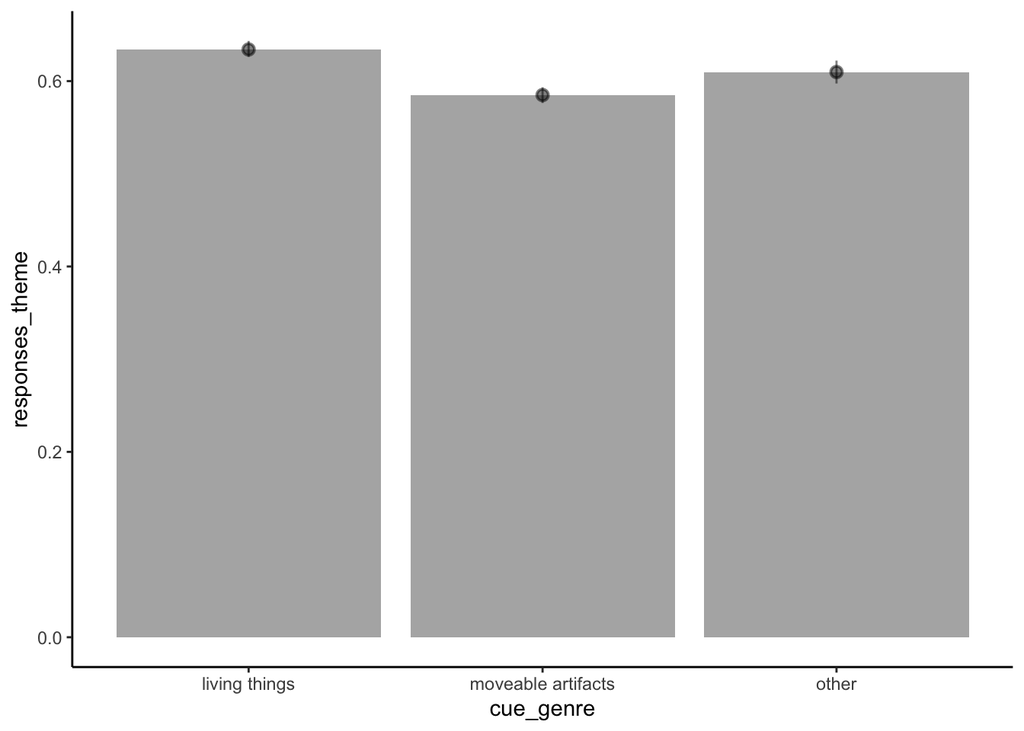

```r
ggplot(data = df) +
   geom_bar(stat = "summary",
            fun.data = "mean_cl_boot",
            alpha = .5,
            mapping = aes(x = cue_genre,
                          y = responses_theme)) +
  geom_pointrange(stat = "summary",
            fun.data = "mean_cl_boot",
            alpha = .5,
            mapping = aes(x = cue_genre,
                          y = responses_theme))
```

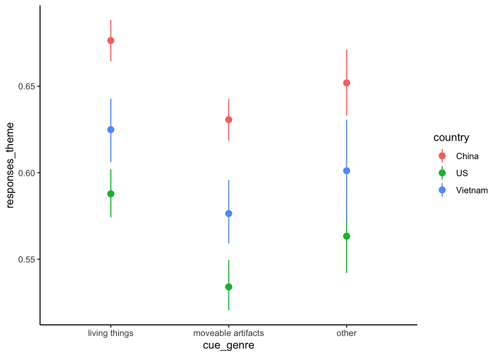

```r
ggplot(data = df,
       mapping = aes(x = cue_genre,
                     y = responses_theme,
                     color = country,
                     fill = country)) +
   stat_summary(fun.data = "mean_cl_boot",
               geom = "pointrange")
#color code by cue genre, spatial sep by country, plotting all triads (mean response)
```

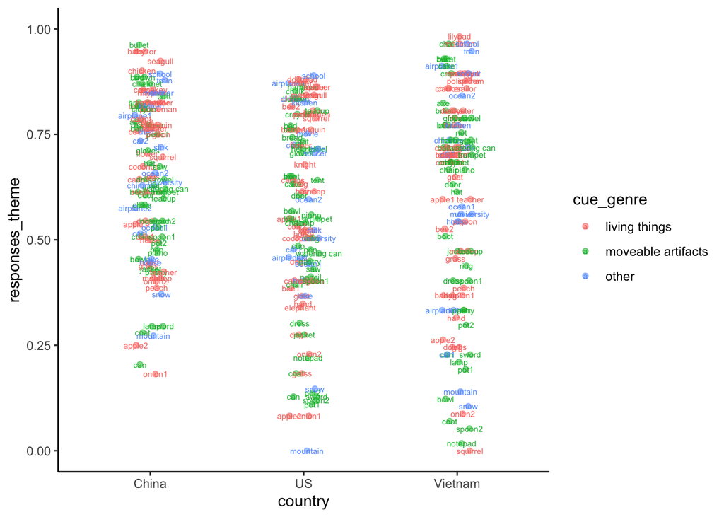

```r
ggplot(data = df,
       mapping = aes(x = country,
                     y = responses_theme,
                     label = triad,
                     group = triad,
                     color = cue_genre)) +
  stat_summary(fun.data = "mean_cl_boot",
               geom = "point",
               alpha = .5,
               position = position_dodge(width = .2)) +
  stat_summary(fun.data = "mean_cl_boot",
               geom = "text",
               position = position_dodge(width = .2), size = 2)
```

There seems to be a clear preference for more thematic matches in the ‘living things’ cues in comparison to the ‘moveable artifacts’ cue. (need to omit cue_genre = “other”)

Comparing some models: Q: SHOULD we look at a model where responses theme is predicted by genre?

### English

Base line model:

```r
# English
fit.EN_US = glmer(responses_theme ~ theme_freq_prop_E + (1 | subject) + (1 | triad),
          data = df %>% filter(country == "US",
                               !(triad %in% triads_omit),
                               !(cue_genre == "other")),
          family="binomial")
summary(fit.EN_US)
fit.EN_US.anova = Anova(fit.EN_US, type = 3)
```

```
Generalized linear mixed model fit by maximum likelihood (Laplace
  Approximation) [glmerMod]
 Family: binomial  ( logit )
Formula: responses_theme ~ theme_freq_prop_E + (1 | subject) + (1 | triad)
   Data:
df %>% filter(country == "US", !(triad %in% triads_omit), !(cue_genre ==
    "other"))

     AIC      BIC   logLik deviance df.resid
  6278.1   6304.8  -3135.0   6270.1     5882

Scaled residuals:
    Min      1Q  Median      3Q     Max
-4.7604 -0.6285  0.2654  0.6117 13.1589

Random effects:
 Groups  Name        Variance Std.Dev.
 subject (Intercept) 0.9924   0.9962
 triad   (Intercept) 1.2199   1.1045
Number of obs: 5886, groups:  subject, 109; triad, 54

Fixed effects:
                  Estimate Std. Error z value Pr(>|z|)
(Intercept)        -1.3784     0.3424  -4.025 5.69e-05 ***
theme_freq_prop_E   2.5121     0.4873   5.155 2.54e-07 ***
---
Signif. codes:  0 '***' 0.001 '**' 0.01 '*' 0.05 '.' 0.1 ' ' 1

Correlation of Fixed Effects:
            (Intr)
thm_frq_p_E -0.849
```

Adding cue genre: significant

```r
fit.EN_US_cue_genre = glmer(responses_theme ~ theme_freq_prop_E + cue_genre + (1 | subject) + (1 | triad),
          data = df %>% filter(country == "US",
                               !(triad %in% triads_omit),
                               !(cue_genre == "other")),
          family="binomial")

summary(fit.EN_US_cue_genre)
Anova(fit.EN_US_cue_genre, type = 3)
```

```
Generalized linear mixed model fit by maximum likelihood (Laplace
  Approximation) [glmerMod]
 Family: binomial  ( logit )
Formula: responses_theme ~ theme_freq_prop_E + cue_genre + (1 | subject) +
    (1 | triad)
   Data:
df %>% filter(country == "US", !(triad %in% triads_omit), !(cue_genre ==
    "other"))

     AIC      BIC   logLik deviance df.resid
  6274.9   6308.3  -3132.4   6264.9     5881

Scaled residuals:
    Min      1Q  Median      3Q     Max
-4.8165 -0.6245  0.2646  0.6118 12.9435

Random effects:
 Groups  Name        Variance Std.Dev.
 subject (Intercept) 0.9925   0.9962
 triad   (Intercept) 1.1004   1.0490
Number of obs: 5886, groups:  subject, 109; triad, 54

Fixed effects:
                            Estimate Std. Error z value Pr(>|z|)
(Intercept)                  -1.1532     0.3408  -3.383 0.000716 ***
theme_freq_prop_E             2.6998     0.4714   5.727 1.02e-08 ***
cue_genremoveable artifacts  -0.6992     0.2979  -2.347 0.018929 *
---
Signif. codes:  0 '***' 0.001 '**' 0.01 '*' 0.05 '.' 0.1 ' ' 1

Correlation of Fixed Effects:
            (Intr) th___E
thm_frq_p_E -0.751
c_gnrmvblar -0.277 -0.175
Analysis of Deviance Table (Type III Wald chisquare tests)

Response: responses_theme
                    Chisq Df Pr(>Chisq)
(Intercept)       11.4468  1  0.0007162 ***
theme_freq_prop_E 32.8005  1  1.021e-08 ***
cue_genre          5.5081  1  0.0189289 *
---
Signif. codes:  0 '***' 0.001 '**' 0.01 '*' 0.05 '.' 0.1 ' ' 1
```

Anova comparison: including cue genre is a better model

```r
fit.EN_US_cue_genre_compare = anova(fit.EN_US, fit.EN_US_cue_genre, type = 3)
fit.EN_US_cue_genre_compare
```

```
Data: df %>% filter(country == "US", !(triad %in% triads_omit), !(cue_genre ==  ...
Models:
fit.EN_US: responses_theme ~ theme_freq_prop_E + (1 | subject) + (1 | triad)
fit.EN_US_cue_genre: responses_theme ~ theme_freq_prop_E + cue_genre + (1 | subject) + (1 | triad)
                    npar    AIC    BIC  logLik deviance  Chisq Df Pr(>Chisq)
fit.EN_US              4 6278.1 6304.8 -3135.1   6270.1
fit.EN_US_cue_genre    5 6274.9 6308.3 -3132.4   6264.9 5.2429  1    0.02204 *
---
Signif. codes:  0 '***' 0.001 '**' 0.01 '*' 0.05 '.' 0.1 ' ' 1
```

### Vietnamese

```r
#Vietnamese
fit.VI_VN = glmer(responses_theme ~ theme_freq_prop_V + (1 | subject) + (1 | triad),
          data = df %>% filter(country == "Vietnam",
                               !(triad %in% triads_omit),
                               !(cue_genre == "other")),
          family="binomial")
summary(fit.VI_VN)
fit.VI_VN.anova = Anova(fit.VI_VN, type = 3)
```

```
Generalized linear mixed model fit by maximum likelihood (Laplace
  Approximation) [glmerMod]
 Family: binomial  ( logit )
Formula: responses_theme ~ theme_freq_prop_V + (1 | subject) + (1 | triad)
   Data: df %>% filter(country == "Vietnam", !(triad %in% triads_omit),
    !(cue_genre == "other"))

     AIC      BIC   logLik deviance df.resid
  3220.0   3244.1  -1606.0   3212.0     3047

Scaled residuals:
    Min      1Q  Median      3Q     Max
-4.3608 -0.6244  0.2359  0.5873  5.3788

Random effects:
 Groups  Name        Variance Std.Dev.
 subject (Intercept) 0.5461   0.739
 triad   (Intercept) 2.1437   1.464
Number of obs: 3051, groups:  subject, 57; triad, 54

Fixed effects:
                  Estimate Std. Error z value Pr(>|z|)
(Intercept)        -0.6707     0.3269  -2.052 0.040207 *
theme_freq_prop_V   1.6543     0.4668   3.544 0.000394 ***
---
Signif. codes:  0 '***' 0.001 '**' 0.01 '*' 0.05 '.' 0.1 ' ' 1

Correlation of Fixed Effects:
            (Intr)
thm_frq_p_V -0.718
```

Adding cue genre: NOT significant

```r
fit.VI_VN_cue_genre = glmer(responses_theme ~ theme_freq_prop_V + cue_genre + (1 | subject) + (1 | triad),
          data = df %>% filter(country == "Vietnam",
                               !(triad %in% triads_omit),
                               !(cue_genre == "other")),
          family="binomial")

summary(fit.VI_VN_cue_genre)
Anova(fit.VI_VN_cue_genre, type = 3)
```

```
Generalized linear mixed model fit by maximum likelihood (Laplace
  Approximation) [glmerMod]
 Family: binomial  ( logit )
Formula: responses_theme ~ theme_freq_prop_V + cue_genre + (1 | subject) +
    (1 | triad)
   Data: df %>% filter(country == "Vietnam", !(triad %in% triads_omit),
    !(cue_genre == "other"))

     AIC      BIC   logLik deviance df.resid
  3220.5   3250.6  -1605.2   3210.5     3046

Scaled residuals:
    Min      1Q  Median      3Q     Max
-4.3042 -0.6251  0.2370  0.5850  5.5112

Random effects:
 Groups  Name        Variance Std.Dev.
 subject (Intercept) 0.546    0.7389
 triad   (Intercept) 2.067    1.4377
Number of obs: 3051, groups:  subject, 57; triad, 54

Fixed effects:
                            Estimate Std. Error z value Pr(>|z|)
(Intercept)                  -0.4976     0.3495  -1.424 0.154529
theme_freq_prop_V             1.8139     0.4765   3.806 0.000141 ***
cue_genremoveable artifacts  -0.5288     0.4196  -1.260 0.207601
---
Signif. codes:  0 '***' 0.001 '**' 0.01 '*' 0.05 '.' 0.1 ' ' 1

Correlation of Fixed Effects:
            (Intr) th___V
thm_frq_p_V -0.531
c_gnrmvblar -0.390 -0.269
Analysis of Deviance Table (Type III Wald chisquare tests)

Response: responses_theme
                    Chisq Df Pr(>Chisq)
(Intercept)        2.0270  1   0.154529
theme_freq_prop_V 14.4890  1   0.000141 ***
cue_genre          1.5881  1   0.207601
---
Signif. codes:  0 '***' 0.001 '**' 0.01 '*' 0.05 '.' 0.1 ' ' 1
```

Anova comparison (also not significant)

```r
fit.VI_VN_cue_genre_compare = anova(fit.VI_VN, fit.VI_VN_cue_genre, type = 3)
fit.VI_VN_cue_genre_compare
```

```
Data: df %>% filter(country == "Vietnam", !(triad %in% triads_omit),  ...
Models:
fit.VI_VN: responses_theme ~ theme_freq_prop_V + (1 | subject) + (1 | triad)
fit.VI_VN_cue_genre: responses_theme ~ theme_freq_prop_V + cue_genre + (1 | subject) + (1 | triad)
                    npar    AIC    BIC  logLik deviance  Chisq Df Pr(>Chisq)
fit.VI_VN              4 3220.0 3244.1 -1606.0   3212.0
fit.VI_VN_cue_genre    5 3220.5 3250.6 -1605.2   3210.5 1.5555  1     0.2123
```

### Mandarin

```r
#Mandarin
fit.ZH_CN = glmer(responses_theme ~ theme_freq_prop_M + (1 | subject) + (1 | triad),
          data = df %>% filter(country == "China",
                               !(triad %in% triads_omit),
                               !(cue_genre == "other")),
          family="binomial")
summary(fit.ZH_CN)
fit.ZH_CN.anova = Anova(fit.ZH_CN, type = 3)
```

```
Generalized linear mixed model fit by maximum likelihood (Laplace
  Approximation) [glmerMod]
 Family: binomial  ( logit )
Formula: responses_theme ~ theme_freq_prop_M + (1 | subject) + (1 | triad)
   Data: df %>% filter(country == "China", !(triad %in% triads_omit),
    !(cue_genre == "other"))

     AIC      BIC   logLik deviance df.resid
  8156.8   8184.3  -4074.4   8148.8     7124

Scaled residuals:
    Min      1Q  Median      3Q     Max
-4.4477 -0.7985  0.3601  0.6911  3.2433

Random effects:
 Groups  Name        Variance Std.Dev.
 subject (Intercept) 0.3641   0.6034
 triad   (Intercept) 0.9170   0.9576
Number of obs: 7128, groups:  subject, 132; triad, 54

Fixed effects:
                  Estimate Std. Error z value Pr(>|z|)
(Intercept)       -0.08323    0.23842  -0.349 0.727029
theme_freq_prop_M  1.35420    0.36544   3.706 0.000211 ***
---
Signif. codes:  0 '***' 0.001 '**' 0.01 '*' 0.05 '.' 0.1 ' ' 1

Correlation of Fixed Effects:
            (Intr)
thm_frq_p_M -0.798
```

Adding cue genre: significant

```r
fit.ZH_CN_cue_genre = glmer(responses_theme ~ theme_freq_prop_M + cue_genre + (1 | subject) + (1 | triad),
          data = df %>% filter(country == "China",
                               !(triad %in% triads_omit),
                               !(cue_genre == "other")),
          family="binomial")

summary(fit.ZH_CN_cue_genre)
Anova(fit.ZH_CN_cue_genre, type = 3)
```

```
Generalized linear mixed model fit by maximum likelihood (Laplace
  Approximation) [glmerMod]
 Family: binomial  ( logit )
Formula: responses_theme ~ theme_freq_prop_M + cue_genre + (1 | subject) +
    (1 | triad)
   Data: df %>% filter(country == "China", !(triad %in% triads_omit),
    !(cue_genre == "other"))

     AIC      BIC   logLik deviance df.resid
  8154.5   8188.9  -4072.3   8144.5     7123

Scaled residuals:
    Min      1Q  Median      3Q     Max
-4.3392 -0.7966  0.3613  0.6914  3.2690

Random effects:
 Groups  Name        Variance Std.Dev.
 subject (Intercept) 0.3641   0.6034
 triad   (Intercept) 0.8442   0.9188
Number of obs: 7128, groups:  subject, 132; triad, 54

Fixed effects:
                            Estimate Std. Error z value Pr(>|z|)
(Intercept)                  0.06944    0.24078   0.288   0.7730
theme_freq_prop_M            1.58364    0.36851   4.297 1.73e-05 ***
cue_genremoveable artifacts -0.56624    0.26944  -2.102   0.0356 *
---
Signif. codes:  0 '***' 0.001 '**' 0.01 '*' 0.05 '.' 0.1 ' ' 1

Correlation of Fixed Effects:
            (Intr) th___M
thm_frq_p_M -0.634
c_gnrmvblar -0.301 -0.301
Analysis of Deviance Table (Type III Wald chisquare tests)

Response: responses_theme
                    Chisq Df Pr(>Chisq)
(Intercept)        0.0832  1    0.77304
theme_freq_prop_M 18.4679  1  1.728e-05 ***
cue_genre          4.4165  1    0.03559 *
---
Signif. codes:  0 '***' 0.001 '**' 0.01 '*' 0.05 '.' 0.1 ' ' 1
```

Anova comparison: including cue genre is a better model

```r
fit.ZH_CN_cue_genre_compare = anova(fit.ZH_CN, fit.ZH_CN_cue_genre, type = 3)
fit.ZH_CN_cue_genre_compare
```

```
Data: df %>% filter(country == "China", !(triad %in% triads_omit),  ...
Models:
fit.ZH_CN: responses_theme ~ theme_freq_prop_M + (1 | subject) + (1 | triad)
fit.ZH_CN_cue_genre: responses_theme ~ theme_freq_prop_M + cue_genre + (1 | subject) + (1 | triad)
                    npar    AIC    BIC  logLik deviance Chisq Df Pr(>Chisq)
fit.ZH_CN              4 8156.8 8184.3 -4074.4   8148.8
fit.ZH_CN_cue_genre    5 8154.5 8188.9 -4072.3   8144.5  4.25  1    0.03925 *
---
Signif. codes:  0 '***' 0.001 '**' 0.01 '*' 0.05 '.' 0.1 ' ' 1
```

When added to the baseline model, cue genre is a significant predictor for US and China responses. But not for Vietnam.

### More general models that predict thematic response based on cue genre

NOT significant when just predicted by cue_genre.

```r
fit.cue_genre = glmer(responses_theme ~ cue_genre + (1 | subject) + (1 | triad),
          data = df %>% filter(!(cue_genre == "other")),
          # no need to pull out triads_omit because we're not using the raw coocurrences
          family="binomial")
summary(fit.cue_genre)
fit.cue_genre.anova = Anova(fit.cue_genre, type = 3)
fit.cue_genre.anova
```

```
Generalized linear mixed model fit by maximum likelihood (Laplace
  Approximation) [glmerMod]
 Family: binomial  ( logit )
Formula: responses_theme ~ cue_genre + (1 | subject) + (1 | triad)
   Data: df %>% filter(!(cue_genre == "other"))

     AIC      BIC   logLik deviance df.resid
 28509.9  28542.5 -14250.9  28501.9    25597

Scaled residuals:
    Min      1Q  Median      3Q     Max
-5.1128 -0.7512  0.3658  0.6583 10.0706

Random effects:
 Groups  Name        Variance Std.Dev.
 subject (Intercept) 0.6494   0.8058
 triad   (Intercept) 1.0251   1.0125
Number of obs: 25601, groups:  subject, 298; triad, 86

Fixed effects:
                            Estimate Std. Error z value Pr(>|z|)
(Intercept)                   0.6935     0.1646   4.213 2.52e-05 ***
cue_genremoveable artifacts  -0.2692     0.2206  -1.220    0.222
---
Signif. codes:  0 '***' 0.001 '**' 0.01 '*' 0.05 '.' 0.1 ' ' 1

Correlation of Fixed Effects:
            (Intr)
c_gnrmvblar -0.686
Analysis of Deviance Table (Type III Wald chisquare tests)

Response: responses_theme
              Chisq Df Pr(>Chisq)
(Intercept) 17.7513  1  2.518e-05 ***
cue_genre    1.4883  1     0.2225
---
Signif. codes:  0 '***' 0.001 '**' 0.01 '*' 0.05 '.' 0.1 ' ' 1
```

NOT significant when predicted by country and cue_genre (only country is significant)

```r
fit.cue_genre_country = glmer(responses_theme ~ country + cue_genre + (1 | subject) + (1 | triad),
          data = df %>% filter(!(cue_genre == "other")),
          # no need to pull out triads_omit because we're not using the raw coocurrences
          family="binomial")
summary(fit.cue_genre_country)
fit.cue_genre_country.anova = Anova(fit.cue_genre_country, type = 3)
fit.cue_genre_country.anova
```

```
Generalized linear mixed model fit by maximum likelihood (Laplace
  Approximation) [glmerMod]
 Family: binomial  ( logit )
Formula: responses_theme ~ country + cue_genre + (1 | subject) + (1 |
    triad)
   Data: df %>% filter(!(cue_genre == "other"))

     AIC      BIC   logLik deviance df.resid
 28488.6  28537.5 -14238.3  28476.6    25595

Scaled residuals:
    Min      1Q  Median      3Q     Max
-5.1619 -0.7502  0.3657  0.6588 10.0772

Random effects:
 Groups  Name        Variance Std.Dev.
 subject (Intercept) 0.591    0.7687
 triad   (Intercept) 1.025    1.0124
Number of obs: 25601, groups:  subject, 298; triad, 86

Fixed effects:
                            Estimate Std. Error z value Pr(>|z|)
(Intercept)                   0.9477     0.1724   5.498 3.85e-08 ***
countryUS                    -0.5355     0.1050  -5.099 3.42e-07 ***
countryVietnam               -0.3042     0.1284  -2.369   0.0178 *
cue_genremoveable artifacts  -0.2691     0.2207  -1.219   0.2227
---
Signif. codes:  0 '***' 0.001 '**' 0.01 '*' 0.05 '.' 0.1 ' ' 1

Correlation of Fixed Effects:
            (Intr) cntrUS cntryV
countryUS   -0.277
countryVtnm -0.226  0.370
c_gnrmvblar -0.656  0.001  0.000
Analysis of Deviance Table (Type III Wald chisquare tests)

Response: responses_theme
              Chisq Df Pr(>Chisq)
(Intercept) 30.2249  1  3.847e-08 ***
country     26.2625  2  1.982e-06 ***
cue_genre    1.4869  1     0.2227
---
Signif. codes:  0 '***' 0.001 '**' 0.01 '*' 0.05 '.' 0.1 ' ' 1
```

NO interaction between country and cue genre either.

```r
fit.cue_genre_country_int = glmer(responses_theme ~ country + cue_genre + country * cue_genre + (1 | subject) + (1 | triad),
          data = df %>% filter(!(cue_genre == "other")),
          # no need to pull out triads_omit because we're not using the raw coocurrences
          family="binomial")
summary(fit.cue_genre_country_int)
fit.cue_genre_country_int.anova = Anova(fit.cue_genre_country_int, type = 3)
fit.cue_genre_country_int.anova
```

```
Generalized linear mixed model fit by maximum likelihood (Laplace
  Approximation) [glmerMod]
 Family: binomial  ( logit )
Formula: responses_theme ~ country + cue_genre + country * cue_genre +
    (1 | subject) + (1 | triad)
   Data: df %>% filter(!(cue_genre == "other"))

     AIC      BIC   logLik deviance df.resid
 28492.3  28557.5 -14238.2  28476.3    25593

Scaled residuals:
    Min      1Q  Median      3Q     Max
-5.1427 -0.7495  0.3661  0.6577 10.0267

Random effects:
 Groups  Name        Variance Std.Dev.
 subject (Intercept) 0.5911   0.7688
 triad   (Intercept) 1.0249   1.0124
Number of obs: 25601, groups:  subject, 298; triad, 86

Fixed effects:
                                            Estimate Std. Error z value
(Intercept)                                 0.941081   0.173272   5.431
countryUS                                  -0.518676   0.110543  -4.692
countryVietnam                             -0.302612   0.135124  -2.240
cue_genremoveable artifacts                -0.256550   0.223148  -1.150
countryUS:cue_genremoveable artifacts      -0.032085   0.065878  -0.487
countryVietnam:cue_genremoveable artifacts -0.002848   0.080245  -0.035
                                           Pr(>|z|)
(Intercept)                                 5.6e-08 ***
countryUS                                   2.7e-06 ***
countryVietnam                               0.0251 *
cue_genremoveable artifacts                  0.2503
countryUS:cue_genremoveable artifacts        0.6262
countryVietnam:cue_genremoveable artifacts   0.9717
---
Signif. codes:  0 '***' 0.001 '**' 0.01 '*' 0.05 '.' 0.1 ' ' 1

Correlation of Fixed Effects:
            (Intr) cntrUS cntryV c_gnra cUS:_a
countryUS   -0.291
countryVtnm -0.238  0.372
c_gnrmvblar -0.660  0.044  0.035
cntryUS:c_a  0.094 -0.312 -0.119 -0.137
cntryVtn:_a  0.076 -0.119 -0.311 -0.112  0.379
Analysis of Deviance Table (Type III Wald chisquare tests)

Response: responses_theme
                    Chisq Df Pr(>Chisq)
(Intercept)       29.4982  1  5.597e-08 ***
country           22.2984  2  1.439e-05 ***
cue_genre          1.3218  1     0.2503
country:cue_genre  0.2631  2     0.8767
---
Signif. codes:  0 '***' 0.001 '**' 0.01 '*' 0.05 '.' 0.1 ' ' 1
```

NOT significance even with country having random slope and intercept for cue_genre.

```r
fit.cue_genre_country_slope = glmer(responses_theme ~ country + cue_genre + (cue_genre | country) + (1 | subject) + (1 | triad),
          data = df %>% filter(!(cue_genre == "other")),
          # no need to pull out triads_omit because we're not using the raw co-ocurrences
          family="binomial")
```

```
boundary (singular) fit: see help('isSingular')
```

```r
summary(fit.cue_genre_country_slope)
fit.cue_genre_country_slope.anova = Anova(fit.cue_genre_country_slope, type = 3)
fit.cue_genre_country_slope.anova
```

```
Generalized linear mixed model fit by maximum likelihood (Laplace
  Approximation) [glmerMod]
 Family: binomial  ( logit )
Formula: responses_theme ~ country + cue_genre + (cue_genre | country) +
    (1 | subject) + (1 | triad)
   Data: df %>% filter(!(cue_genre == "other"))

     AIC      BIC   logLik deviance df.resid
 28494.6  28567.9 -14238.3  28476.6    25592

Scaled residuals:
    Min      1Q  Median      3Q     Max
-5.1619 -0.7502  0.3657  0.6588 10.0771

Random effects:
 Groups  Name                        Variance  Std.Dev.  Corr
 subject (Intercept)                 5.910e-01 0.7687352
 triad   (Intercept)                 1.025e+00 1.0123734
 country (Intercept)                 0.000e+00 0.0000000
         cue_genremoveable artifacts 1.109e-08 0.0001053  NaN
Number of obs: 25601, groups:  subject, 298; triad, 86; country, 3

Fixed effects:
                            Estimate Std. Error z value Pr(>|z|)
(Intercept)                   0.9477     0.1724   5.498 3.84e-08 ***
countryUS                    -0.5355     0.1050  -5.099 3.41e-07 ***
countryVietnam               -0.3042     0.1284  -2.369   0.0178 *
cue_genremoveable artifacts  -0.2691     0.2207  -1.220   0.2226
---
Signif. codes:  0 '***' 0.001 '**' 0.01 '*' 0.05 '.' 0.1 ' ' 1

Correlation of Fixed Effects:
            (Intr) cntrUS cntryV
countryUS   -0.277
countryVtnm -0.226  0.371
c_gnrmvblar -0.656  0.001  0.000
optimizer (Nelder_Mead) convergence code: 0 (OK)
boundary (singular) fit: see help('isSingular')

Analysis of Deviance Table (Type III Wald chisquare tests)

Response: responses_theme
              Chisq Df Pr(>Chisq)
(Intercept) 30.2297  1  3.838e-08 ***
country     26.2675  2  1.977e-06 ***
cue_genre    1.4876  1     0.2226
---
Signif. codes:  0 '***' 0.001 '**' 0.01 '*' 0.05 '.' 0.1 ' ' 1
```

## Do people make more thematic matches for certain semantic groups of thematic relationships?

Plotting mean response theme by country, by type of thematic match

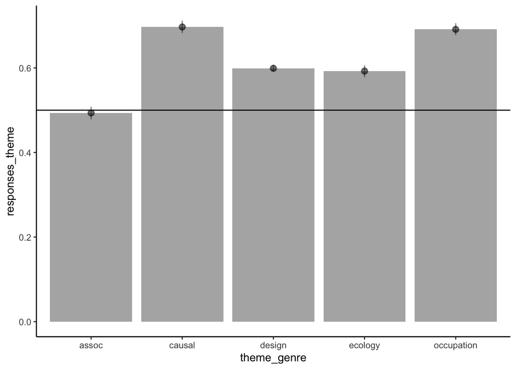

```r
ggplot(data = df) +
   geom_bar(stat = "summary",
            fun.data = "mean_cl_boot",
            alpha = .5,
            mapping = aes(x = theme_genre,
                          y = responses_theme)) +
  geom_pointrange(stat = "summary",
            fun.data = "mean_cl_boot",
            alpha = .5,
            mapping = aes(x = theme_genre,
                          y = responses_theme)) +
  geom_hline(yintercept = 0.5)
```

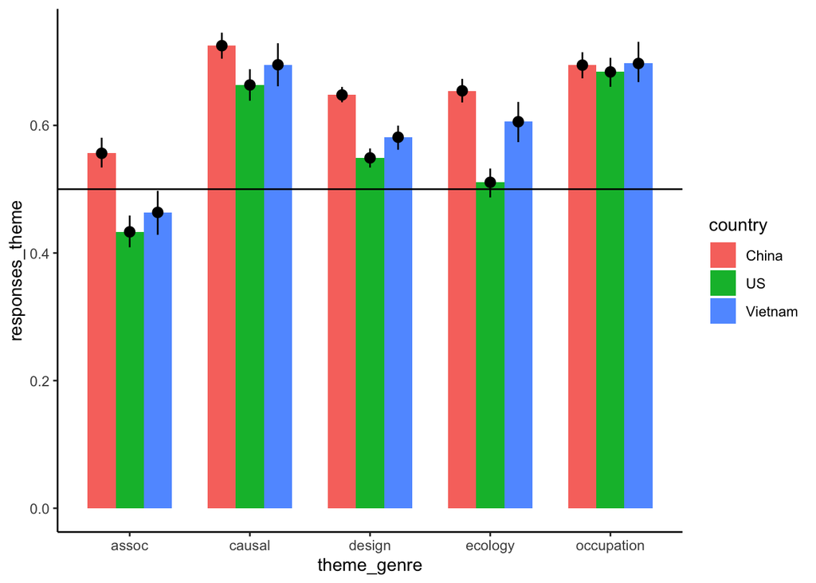

```r
ggplot(data = df) +
   geom_bar(stat = "summary",
            fun.data = "mean_cl_boot",
            mapping = aes(x = theme_genre,
                          y = responses_theme,
                          fill = country),
            position = position_dodge(width = .7), width = .7) +
  geom_pointrange(stat = "summary",
            fun.data = "mean_cl_boot",
            mapping = aes(x = theme_genre,
                          y = responses_theme,
                          group = country),
            position = position_dodge(width = .7)) +
  geom_hline(yintercept = 0.5)
#color code by cue genre, spatial sep by country, plotting all triads (mean response)
```

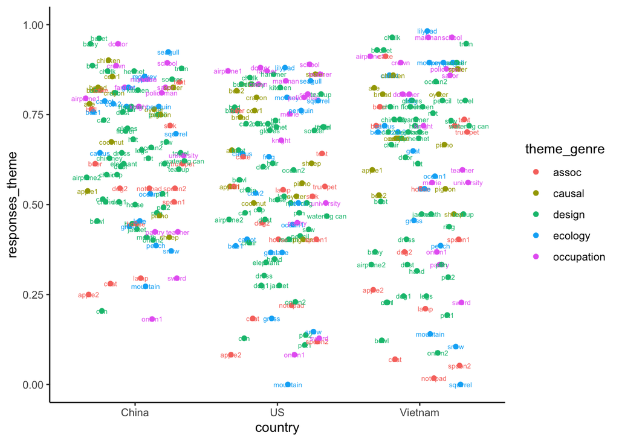

```r
ggplot(data = df,
       mapping = aes(x = country,
                     y = responses_theme,
                     label = triad,
                     group = triad,
                     color = theme_genre)) +
  stat_summary(fun.data = "mean_cl_boot",
               geom = "point",
               position = position_dodge(width = .7)) +
  stat_summary(fun.data = "mean_cl_boot",
               geom = "text",
               position = position_dodge(width = .7), size = 2)


  # geom_point(data = df %>% filter(theme_genre == 'causal'),
  #            mapping = aes(x = country,
  #                    y = responses_theme,
  #                    label = triad,
  #                    group = triad,
  #                    color = theme_genre),
  #            stat = "summary",
  #            fun.data = "mean_cl_boot",
  #            position = position_dodge(width =.2))
```

### English

Base line model:

```r
# English
fit.EN_US = glmer(responses_theme ~ theme_freq_prop_E + (1 | subject) + (1 | triad),
          data = df %>% filter(country == "US",
                               !(triad %in% triads_omit),
                               !(cue_genre == "other")),
          family="binomial")
summary(fit.EN_US)
fit.EN_US.anova = Anova(fit.EN_US, type = 3)
```

```
Generalized linear mixed model fit by maximum likelihood (Laplace
  Approximation) [glmerMod]
 Family: binomial  ( logit )
Formula: responses_theme ~ theme_freq_prop_E + (1 | subject) + (1 | triad)
   Data:
df %>% filter(country == "US", !(triad %in% triads_omit), !(cue_genre ==
    "other"))

     AIC      BIC   logLik deviance df.resid
  6278.1   6304.8  -3135.0   6270.1     5882

Scaled residuals:
    Min      1Q  Median      3Q     Max
-4.7604 -0.6285  0.2654  0.6117 13.1589

Random effects:
 Groups  Name        Variance Std.Dev.
 subject (Intercept) 0.9924   0.9962
 triad   (Intercept) 1.2199   1.1045
Number of obs: 5886, groups:  subject, 109; triad, 54

Fixed effects:
                  Estimate Std. Error z value Pr(>|z|)
(Intercept)        -1.3784     0.3424  -4.025 5.69e-05 ***
theme_freq_prop_E   2.5121     0.4873   5.155 2.54e-07 ***
---
Signif. codes:  0 '***' 0.001 '**' 0.01 '*' 0.05 '.' 0.1 ' ' 1

Correlation of Fixed Effects:
            (Intr)
thm_frq_p_E -0.849
```

Adding theme genre: NOT significant (p = 0.08)

```r
fit.EN_US_theme_genre = glmer(responses_theme ~ theme_freq_prop_E + theme_genre + (1 | subject) + (1 | triad),
          data = df %>% filter(country == "US",
                               !(triad %in% triads_omit),
                               !(cue_genre == "other")),
          family="binomial")

summary(fit.EN_US_theme_genre)
Anova(fit.EN_US_theme_genre, type = 3)
```

```
Generalized linear mixed model fit by maximum likelihood (Laplace
  Approximation) [glmerMod]
 Family: binomial  ( logit )
Formula: responses_theme ~ theme_freq_prop_E + theme_genre + (1 | subject) +
    (1 | triad)
   Data:
df %>% filter(country == "US", !(triad %in% triads_omit), !(cue_genre ==
    "other"))

     AIC      BIC   logLik deviance df.resid
  6278.3   6331.8  -3131.2   6262.3     5878

Scaled residuals:
    Min      1Q  Median      3Q     Max
-4.8744 -0.6244  0.2623  0.6118 13.4481

Random effects:
 Groups  Name        Variance Std.Dev.
 subject (Intercept) 0.9934   0.9967
 triad   (Intercept) 1.0473   1.0234
Number of obs: 5886, groups:  subject, 109; triad, 54

Fixed effects:
                      Estimate Std. Error z value Pr(>|z|)
(Intercept)            -1.9537     0.4363  -4.478 7.53e-06 ***
theme_freq_prop_E       2.2999     0.4738   4.854 1.21e-06 ***
theme_genrecausal       1.2211     0.5131   2.380   0.0173 *
theme_genredesign       0.6870     0.3938   1.744   0.0811 .
theme_genreecology      0.7285     0.5187   1.405   0.1602
theme_genreoccupation   1.4860     0.6291   2.362   0.0182 *
---
Signif. codes:  0 '***' 0.001 '**' 0.01 '*' 0.05 '.' 0.1 ' ' 1

Correlation of Fixed Effects:
            (Intr) th___E thm_gnrcs thm_gnrd thm_gnrcl
thm_frq_p_E -0.608
them_gnrcsl -0.359 -0.226
thm_gnrdsgn -0.661  0.025  0.543
thm_gnrclgy -0.453 -0.061  0.431     0.541
thm_gnrccpt -0.395 -0.016  0.348     0.447    0.341
Analysis of Deviance Table (Type III Wald chisquare tests)

Response: responses_theme
                    Chisq Df Pr(>Chisq)
(Intercept)       20.0547  1  7.526e-06 ***
theme_freq_prop_E 23.5626  1  1.209e-06 ***
theme_genre        8.3435  4    0.07978 .
---
Signif. codes:  0 '***' 0.001 '**' 0.01 '*' 0.05 '.' 0.1 ' ' 1
```

Anova comparison: including theme genre is NOT a better model

```r
fit.EN_US_theme_genre_compare = anova(fit.EN_US, fit.EN_US_theme_genre, type = 3)
fit.EN_US_theme_genre_compare
```

```
Data: df %>% filter(country == "US", !(triad %in% triads_omit), !(cue_genre ==  ...
Models:
fit.EN_US: responses_theme ~ theme_freq_prop_E + (1 | subject) + (1 | triad)
fit.EN_US_theme_genre: responses_theme ~ theme_freq_prop_E + theme_genre + (1 | subject) + (1 | triad)
                      npar    AIC    BIC  logLik deviance  Chisq Df Pr(>Chisq)
fit.EN_US                4 6278.1 6304.8 -3135.1   6270.1
fit.EN_US_theme_genre    8 6278.3 6331.8 -3131.2   6262.3 7.7645  4     0.1006
```

### Vietnamese

```r
#Vietnamese
fit.VI_VN = glmer(responses_theme ~ theme_freq_prop_V + (1 | subject) + (1 | triad),
          data = df %>% filter(country == "Vietnam",
                               !(triad %in% triads_omit),
                               !(cue_genre == "other")),
          family="binomial")
summary(fit.VI_VN)
fit.VI_VN.anova = Anova(fit.VI_VN, type = 3)
```

```
Generalized linear mixed model fit by maximum likelihood (Laplace
  Approximation) [glmerMod]
 Family: binomial  ( logit )
Formula: responses_theme ~ theme_freq_prop_V + (1 | subject) + (1 | triad)
   Data: df %>% filter(country == "Vietnam", !(triad %in% triads_omit),
    !(cue_genre == "other"))

     AIC      BIC   logLik deviance df.resid
  3220.0   3244.1  -1606.0   3212.0     3047

Scaled residuals:
    Min      1Q  Median      3Q     Max
-4.3608 -0.6244  0.2359  0.5873  5.3788

Random effects:
 Groups  Name        Variance Std.Dev.
 subject (Intercept) 0.5461   0.739
 triad   (Intercept) 2.1437   1.464
Number of obs: 3051, groups:  subject, 57; triad, 54

Fixed effects:
                  Estimate Std. Error z value Pr(>|z|)
(Intercept)        -0.6707     0.3269  -2.052 0.040207 *
theme_freq_prop_V   1.6543     0.4668   3.544 0.000394 ***
---
Signif. codes:  0 '***' 0.001 '**' 0.01 '*' 0.05 '.' 0.1 ' ' 1

Correlation of Fixed Effects:
            (Intr)
thm_frq_p_V -0.718
```

Adding theme genre: significant (p < 0.05)

```r
fit.VI_VN_theme_genre = glmer(responses_theme ~ theme_freq_prop_V + theme_genre + (1 | subject) + (1 | triad),
          data = df %>% filter(country == "Vietnam",
                               !(triad %in% triads_omit),
                               !(cue_genre == "other")),
          family="binomial")

summary(fit.VI_VN_theme_genre)
Anova(fit.VI_VN_theme_genre, type = 3)
```

```
Generalized linear mixed model fit by maximum likelihood (Laplace
  Approximation) [glmerMod]
 Family: binomial  ( logit )
Formula: responses_theme ~ theme_freq_prop_V + theme_genre + (1 | subject) +
    (1 | triad)
   Data: df %>% filter(country == "Vietnam", !(triad %in% triads_omit),
    !(cue_genre == "other"))

     AIC      BIC   logLik deviance df.resid
  3218.5   3266.7  -1601.3   3202.5     3043

Scaled residuals:
    Min      1Q  Median      3Q     Max
-4.2936 -0.6232  0.2418  0.5861  5.7968

Random effects:
 Groups  Name        Variance Std.Dev.
 subject (Intercept) 0.5453   0.7384
 triad   (Intercept) 1.7450   1.3210
Number of obs: 3051, groups:  subject, 57; triad, 54

Fixed effects:
                      Estimate Std. Error z value Pr(>|z|)
(Intercept)            -1.8417     0.5151  -3.575  0.00035 ***
theme_freq_prop_V       1.7605     0.4372   4.027 5.65e-05 ***
theme_genrecausal       1.9133     0.6512   2.938  0.00330 **
theme_genredesign       1.1039     0.5175   2.133  0.03292 *
theme_genreecology      1.6563     0.6927   2.391  0.01680 *
theme_genreoccupation   1.4363     0.8128   1.767  0.07719 .
---
Signif. codes:  0 '***' 0.001 '**' 0.01 '*' 0.05 '.' 0.1 ' ' 1

Correlation of Fixed Effects:
            (Intr) th___V thm_gnrcs thm_gnrd thm_gnrcl
thm_frq_p_V -0.492
them_gnrcsl -0.592  0.042
thm_gnrdsgn -0.755  0.074  0.572
thm_gnrclgy -0.629  0.188  0.432     0.548
thm_gnrccpt -0.417 -0.083  0.359     0.450    0.324
Analysis of Deviance Table (Type III Wald chisquare tests)

Response: responses_theme
                   Chisq Df Pr(>Chisq)
(Intercept)       12.783  1  0.0003498 ***
theme_freq_prop_V 16.218  1  5.645e-05 ***
theme_genre       10.462  4  0.0333248 *
---
Signif. codes:  0 '***' 0.001 '**' 0.01 '*' 0.05 '.' 0.1 ' ' 1
```

Anova comparison: significant

```r
fit.VI_VN_theme_genre_compare = anova(fit.VI_VN, fit.VI_VN_theme_genre, type = 3)
fit.VI_VN_theme_genre_compare
```

```
Data: df %>% filter(country == "Vietnam", !(triad %in% triads_omit),  ...
Models:
fit.VI_VN: responses_theme ~ theme_freq_prop_V + (1 | subject) + (1 | triad)
fit.VI_VN_theme_genre: responses_theme ~ theme_freq_prop_V + theme_genre + (1 | subject) + (1 | triad)
                      npar    AIC    BIC  logLik deviance  Chisq Df Pr(>Chisq)
fit.VI_VN                4 3220.0 3244.1 -1606.0   3212.0
fit.VI_VN_theme_genre    8 3218.5 3266.7 -1601.3   3202.5 9.5124  4    0.04949

fit.VI_VN
fit.VI_VN_theme_genre *
---
Signif. codes:  0 '***' 0.001 '**' 0.01 '*' 0.05 '.' 0.1 ' ' 1
```

### Mandarin

```r
#Mandarin
fit.ZH_CN = glmer(responses_theme ~ theme_freq_prop_M + (1 | subject) + (1 | triad),
          data = df %>% filter(country == "China",
                               !(triad %in% triads_omit),
                               !(cue_genre == "other")),
          family="binomial")
summary(fit.ZH_CN)
fit.ZH_CN.anova = Anova(fit.ZH_CN, type = 3)
```

```
Generalized linear mixed model fit by maximum likelihood (Laplace
  Approximation) [glmerMod]
 Family: binomial  ( logit )
Formula: responses_theme ~ theme_freq_prop_M + (1 | subject) + (1 | triad)
   Data: df %>% filter(country == "China", !(triad %in% triads_omit),
    !(cue_genre == "other"))

     AIC      BIC   logLik deviance df.resid
  8156.8   8184.3  -4074.4   8148.8     7124

Scaled residuals:
    Min      1Q  Median      3Q     Max
-4.4477 -0.7985  0.3601  0.6911  3.2433

Random effects:
 Groups  Name        Variance Std.Dev.
 subject (Intercept) 0.3641   0.6034
 triad   (Intercept) 0.9170   0.9576
Number of obs: 7128, groups:  subject, 132; triad, 54

Fixed effects:
                  Estimate Std. Error z value Pr(>|z|)
(Intercept)       -0.08323    0.23842  -0.349 0.727029
theme_freq_prop_M  1.35420    0.36544   3.706 0.000211 ***
---
Signif. codes:  0 '***' 0.001 '**' 0.01 '*' 0.05 '.' 0.1 ' ' 1

Correlation of Fixed Effects:
            (Intr)
thm_frq_p_M -0.798
```

Adding theme genre: NOT significant (p = 0.12)

```r
fit.ZH_CN_theme_genre = glmer(responses_theme ~ theme_freq_prop_M + theme_genre + (1 | subject) + (1 | triad),
          data = df %>% filter(country == "China",
                               !(triad %in% triads_omit),
                               !(cue_genre == "other")),
          family="binomial")

summary(fit.ZH_CN_theme_genre)
Anova(fit.ZH_CN_theme_genre, type = 3)
```

```
Generalized linear mixed model fit by maximum likelihood (Laplace
  Approximation) [glmerMod]
 Family: binomial  ( logit )
Formula: responses_theme ~ theme_freq_prop_M + theme_genre + (1 | subject) +
    (1 | triad)
   Data: df %>% filter(country == "China", !(triad %in% triads_omit),
    !(cue_genre == "other"))

     AIC      BIC   logLik deviance df.resid
    8158     8213    -4071     8142     7120

Scaled residuals:
    Min      1Q  Median      3Q     Max
-4.3562 -0.7972  0.3598  0.6894  3.2278

Random effects:
 Groups  Name        Variance Std.Dev.
 subject (Intercept) 0.3641   0.6034
 triad   (Intercept) 0.8001   0.8945
Number of obs: 7128, groups:  subject, 132; triad, 54

Fixed effects:
                      Estimate Std. Error z value Pr(>|z|)
(Intercept)            -0.6593     0.3428  -1.923 0.054452 .
theme_freq_prop_M       1.3099     0.3452   3.794 0.000148 ***
theme_genrecausal       1.0704     0.4375   2.447 0.014412 *
theme_genredesign       0.5839     0.3429   1.703 0.088603 .
theme_genreecology      0.9181     0.4521   2.031 0.042294 *
theme_genreoccupation   0.6847     0.5473   1.251 0.210908
---
Signif. codes:  0 '***' 0.001 '**' 0.01 '*' 0.05 '.' 0.1 ' ' 1

Correlation of Fixed Effects:
            (Intr) th___M thm_gnrcs thm_gnrd thm_gnrcl
thm_frq_p_M -0.514
them_gnrcsl -0.516 -0.082
thm_gnrdsgn -0.707 -0.010  0.559
thm_gnrclgy -0.556  0.031  0.421     0.540
thm_gnrccpt -0.465  0.038  0.346     0.446    0.339
Analysis of Deviance Table (Type III Wald chisquare tests)

Response: responses_theme
                    Chisq Df Pr(>Chisq)
(Intercept)        3.6988  1  0.0544523 .
theme_freq_prop_M 14.3959  1  0.0001481 ***
theme_genre        7.2480  4  0.1233468
---
Signif. codes:  0 '***' 0.001 '**' 0.01 '*' 0.05 '.' 0.1 ' ' 1
```

```r
fit.ZH_CN_theme_genre_compare = anova(fit.ZH_CN, fit.ZH_CN_theme_genre, type = 3)
fit.ZH_CN_theme_genre_compare
```

```
Data: df %>% filter(country == "China", !(triad %in% triads_omit),  ...
Models:
fit.ZH_CN: responses_theme ~ theme_freq_prop_M + (1 | subject) + (1 | triad)
fit.ZH_CN_theme_genre: responses_theme ~ theme_freq_prop_M + theme_genre + (1 | subject) + (1 | triad)
                      npar    AIC    BIC  logLik deviance  Chisq Df Pr(>Chisq)
fit.ZH_CN                4 8156.8 8184.3 -4074.4   8148.8
fit.ZH_CN_theme_genre    8 8158.0 8213.0 -4071.0   8142.0 6.7907  4     0.1474
```

When added to the baseline model, theme genre is a significant predictor for Vietnam response, but not for US and China!

```r
text_tbl <- data.frame(
  Country = c("US", "China", "Vietnam"),
  Add_Cue_Genre = c(
    "significant", "significant", "not significant"
  ),
  Add_Theme_Genre = c(
    "not significant", "not significant", "significant"
  )
)
kable(text_tbl)
```

| Country | Add_Cue_Genre | Add_Theme_Genre |
| --- | --- | --- |
| US | significant | not significant |
| China | significant | not significant |
| Vietnam | not significant | significant |